# Searching for opportunities to maximise conversion rate when selling XYZ's service to restaurants

XYZ company provides staff trainings for restaurants to improve their service quality.

As we all know, restaraunts industry havily relies on customers' reviews on top platforms (Goodle reviews, Yelp, Tripadvisor). Therefore, the first task was to find a dataset with large amounts of customer reviews that we could use for our analysis. There is one great place to start the search from - Kaggle, an online community of data scientists and machine learning practitioners. After spending some time we were able to find and download official Yelp restaurants dataset (5GB).

More facts supporting our incentive for NLP analysis (taken from dataset description):

```
"Yelp restaurant reviews affected consumers' food choice decision-making; a one-star increase led to 59% increase in revenue of independent restaurants (Luca, 2011)."
```

We will analyse 5GB dataset from Yelp to find the most criticised areas and suggest XYZ management which restaurants to approach to maximise revenue from selling their trainings. Key objectives:

1. Clean and aggregate reviews to find most problematic restaurants areas
2. Perform backet of words segmentation for service-related reviews
3. Calculate service problems weight coefficient to answer the main question - "Which restaurants to contact to sell XYZ trainings?"

## 0. Preparation Stage

### Preparing python environment:

```python
import json
import pandas as pd
import numpy as np
import re

#activating interactive shell
from IPython.core.interactiveshell import InteractiveShell
InteractiveShell.ast_node_interactivity = "all"
```

### Data Import & Cleaning

```python
#defining function to load n-rows from 5GB Yelp dataset
def load_rows(filepath, nrows = None):
    with open(filepath) as json_file:
        count = 0
        objs = []
        line = json_file.readline()
        while (nrows is None or count < nrows) and line:
            count += 1
            obj = json.loads(line)
            objs.append(obj)
            line = json_file.readline()
        return pd.DataFrame(objs)
```

```
Above we have defined a function to load part of the whole dataset. Otherwise, our PC wouldnt be capable of processing so large amound of data. After we perofrm main analysis and reach the end of this report, we can load the dataset to Google Cloud Platform or even Kaggle Analytics for full 5GB analysis.
```

```python
#importing and merging on business_id
reviews = load_rows('yelp_reviews.json', nrows=100000)
business_id = load_rows('yelp_business.json', nrows=100000)

combined_all = pd.merge(left=reviews, right=business_id, how='left', on='business_id')

combined_all.info()
```

```
<class 'pandas.core.frame.DataFrame'>
Int64Index: 100000 entries, 0 to 99999
Data columns (total 22 columns):
 #   Column        Non-Null Count   Dtype
---  ------        --------------   -----
 0   review_id     100000 non-null  object
 1   user_id       100000 non-null  object
 2   business_id   100000 non-null  object
 3   stars_x       100000 non-null  float64
 4   useful        100000 non-null  int64
 5   funny         100000 non-null  int64
 6   cool          100000 non-null  int64
 7   text          100000 non-null  object
 8   date          100000 non-null  object
 9   name          100000 non-null  object
 10  address       100000 non-null  object
 11  city          100000 non-null  object
 12  state         100000 non-null  object
 13  postal_code   100000 non-null  object
 14  latitude      100000 non-null  float64
 15  longitude     100000 non-null  float64
 16  stars_y       100000 non-null  float64
 17  review_count  100000 non-null  int64
 18  is_open       100000 non-null  int64
 19  attributes    97370 non-null   object
 20  categories    99981 non-null   object
 21  hours         92517 non-null   object
dtypes: float64(4), int64(5), object(13)
memory usage: 17.5+ MB
```

```python
#printing first 3 rows
combined.head(3)
```

[output not shown]

[output not shown]

#### Data manipulations to clean the data

```python
#deleting reviews with review rating > 3
combined_all = combined_all[combined_all['stars_x']<=3]
```

```python
#deleting unnessesary columns:
main_columns = ['stars_x', 'text', 'date','name', 'stars_y', 'review_count', 'attributes', 'categories']
combined_col = combined_all[main_columns]
```

```python
#removing all rows where category is None:
combined_nnone = combined_col[combined_col['categories'].replace(r'\bNone\b', np.nan).notnull()]
```

```python
#removing all businesses other than restaurants
bool_restaurants = combined_nnone['categories'].copy().str.contains(r'restaurant', flags=re.I)
bool_casino = combined_nnone['categories'].copy().str.contains(r'casino', flags=re.I)

combined = combined_nnone[bool_restaurants & ~bool_casino].reset_index().drop(columns=['index'])
```

```python
#converting date column to datetime format
combined['date'] = pd.to_datetime(combined['date'])

print('Most recent date:', combined['date'].max())
print('The latest date: ', combined['date'].min())
```

```
Most recent date: 2018-10-04 16:27:47
The latest date:  2005-04-14 18:26:11
```

```
Subset that we loaded (10% from all data) has time interval from 2005.04 to 2018.10. Even though the 2005 seems too late of a date, we dont mind because right now our task is to perform main analysis and then we will do all (5GB) analysis in cloud.
```

#### Calculating final dataset size after all transformations/cleanings:

```python
combined.shape
```

```
(21825, 8)
```

```
After removing unnessesary columns and good reviews (since we are conserned with bad ones only), dataset lost 14 columns and 80% of rows.
```

## 1.1 Preparing reviews' text for NLP analysis

```python
#choosing TOP 100 most popular (according to No. of reviews) places
top_names = combined['name'].value_counts().index[0:100]

names_bool=[]
for name in combined['name']:
    names_bool.append(name in top_names)

combined = combined[names_bool]
```

```
We decided to pick only top 100 most popular restaurants becuase others have very little amount of reviews and hence our analysing would be statistically insignificant.
```

```
Performing test cleaning is lenghthy process and we are not going to do it manually for each review our of 20,000. We are going to define cleaning function to do everything for us:
```

```python
#prepare NLP environment
import re
import string
import nltk
import spacy

from nltk.corpus import stopwords
from nltk import PorterStemmer
from nltk.stem.snowball import SnowballStemmer

#assigning spicy function to load_en
nlp = spacy.load('en')

#loading stop words
stopwords = load_en.Defaults.stop_words
#stopwords = stopwords.add('-PRON-').add('restaurant').add('food')

def clean_text(text):

    text_cleaned = text

    #converting to spicy object
    text_cleaned = load_en(text_cleaned)

    #lemmatization & keeping only NOUNs since they indicate specific problems
    text_cleaned = [word.lemma_ for word in text_cleaned if word.pos_=='NOUN']

    #removing stopwords
    text_cleaned = " ".join([word for word in text_cleaned if word not in stopwords])

    return text_cleaned
```

```
Above we have succesfully defined nessesary function. Time to use it for cleaning!
```

```python
#applying our function to clean reviews' text
combined['cleaned_text'] = combined['text'].apply([lambda x: clean_text(x)])
```

```
Now, after cleaning reviews, we need to visualise frequency of most popular words (nouns) in bad reviews to really see what customers dont like. For this we are going to define another plot function to create plots for multiple restaurants:
```

```python
import matplotlib.pyplot as plt
import seaborn as sns

def FreqDist(words):
    freq = {}
    for word in words:
        if word in freq:
            freq[word]+=1
        else:
            freq[word]=1
    return freq


# function to plot most frequent terms
def freq_words(x, terms = 5, graph=True, table=True):

    all_words = ' '.join([text for text in x])
    all_words = all_words.split()
    all_words = [word for word in all_words if word not in ['restaurant']]
    fdist = FreqDist(all_words)
    words_df = pd.DataFrame({'word':list(fdist.keys()),'count':list(fdist.values())})

    if graph:
        # selecting top N most frequent words
        d = words_df.nlargest(columns="count", n = terms)
        plt.figure(figsize=(20,5))
        ax = sns.barplot(data=d, x= d["word"], y = d["count"])
        ax.set(ylabel = 'Count')
        plt.show()

    if table:
        return words_df.nlargest(columns="count", n=terms)
```

## 1.2 Finding most problemtatic restaurants areas

```
Top topics for customer's complains across all restaurants:
```

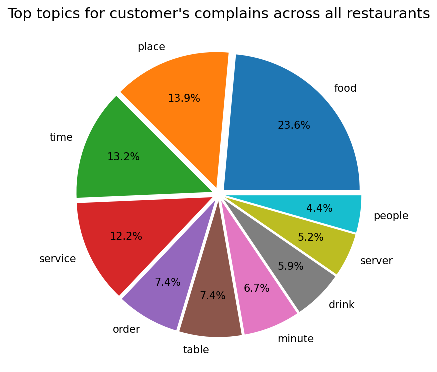

```python
#extracting most popular complains amoung all restaurans
top_complains = freq_words(combined['cleaned_text'], terms=10, graph=False)

#generating plot using MatPlotLib library
fig, ax = plt.subplots(figsize=(10,6), dpi=150)
labels=top_complains['word']
plt.pie(x=top_complains['count'], autopct="%.1f%%", explode=[0.05]*len(top_complains['count']),
        labels=labels, pctdistance=0.7)
plt.title("Top topics for customer's complains across all restaurants", fontsize=14);
```

```
As we can see, most problematic areas for ALL restaurants are:
1. Food
2. Place (atmosphere, interior)
3. Waiting time
4. Service
4. Orders

Lets look at the most problematic areas for top 5 most popular restaurants (according to number of reviews):
```

```
      Reviews analysis for McDonald's based on 185 reviews
```

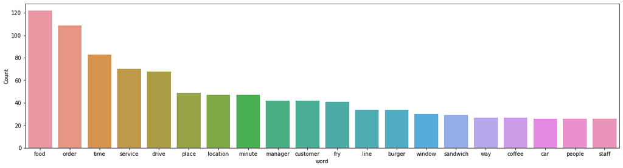

```
      Reviews analysis for Bouchon based on 152 reviews
```

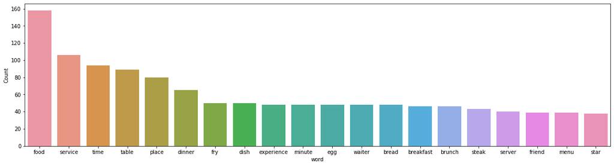

```
      Reviews analysis for Mesa Grill based on 151 reviews
```

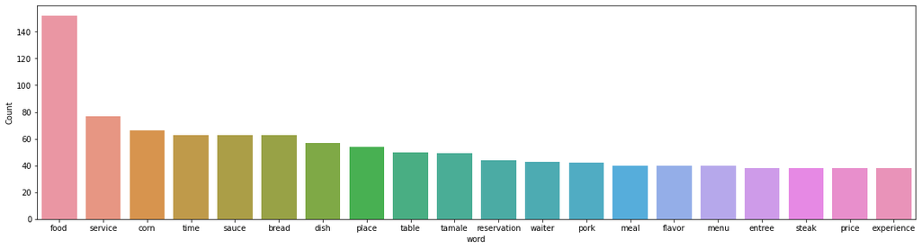

```
      Reviews analysis for Chipotle Mexican Grill based on 146 reviews
```

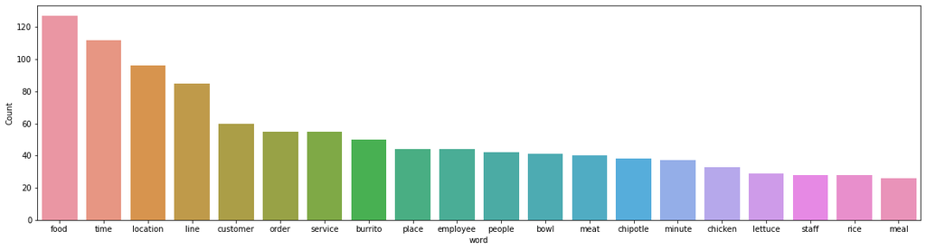

```
      Reviews analysis for Corner Market Buffet based on 125 reviews
```

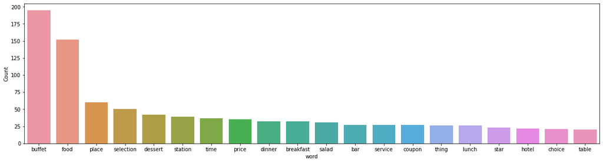

```python
# selecting year 2016 and later
bool_datetime = combined['date'].dt.year==2016

# extracting restaraunts names
r_names = combined['name'].value_counts().index[0:5]

for name in r_names:

    name_reviews = combined[combined['name']==name]

    name_neg_rev = name_reviews[name_reviews['stars_x']<=3]

    print('\n      Reviews analysis for {} based on {} reviews'.format(name, len(name_reviews)))
    freq_words(name_neg_rev['cleaned_text'], table=False, terms=20)
```

## 2-3. Performing basket analysis and calculating service problems coefficient

[output not shown]

```python
worst_service = combined.groupby(['name'])['text'].apply(','.join)

worst_service=pd.DataFrame(worst_service)
worst_service['service_weight'] = round(worst_service['text'].str.count(r'service|staff|time|waiter|manager|server|order|place')\
                                        /worst_service['text'].str.split().str.len()*100, 2)
worst_service = worst_service.sort_values('service_weight', ascending=False)

worst_service.iloc[:20,1]
```

```
name
Matsuda Japanese Cuisine           2.02
Steak ’n Shake                     1.98
Outback Steakhouse                 1.85
Salty Senorita                     1.83
Buffalo Wild Wings                 1.81
Benihana                           1.71
Marché Bacchus                     1.71
Applebee's Grill + Bar             1.70
Miller's Ale House - Henderson     1.69
IHOP                               1.68
Olive Garden Italian Restaurant    1.65
Tropical Smoothie Cafe             1.60
Gangnam Asian BBQ Dining           1.60
Sakana                             1.55
Black Bear Diner                   1.54
Zinburger                          1.53
Coca Cafe                          1.52
Roxy's Diner                       1.51
Giordanos - Arrowhead              1.50
Bahama Breeze                      1.48
Name: service_weight, dtype: float64
```

```
Calculated coefficients represent the size of service problems. Moreover, these coefficients are sorted from top to bottom, so Matsuda with 2.02 has the most service-related problems and is the best restaurant to be contacted to sell our services. For now we will recommend management to contact these top 20 restaurants while we continue by moving to google cloud to analyse all 5GB dataset.
```